# MATH 140 PreLab 1: Welcome to RStudio

### Examples

1. What does this code give?

```r
max(wildcats$W)
```

```
## [1] 51
```

ANSWER: The maximum number of wins in a season over this time period.

Which season was this? Here’s a way to extract the entire season (row) from the data matrix that had the most number of wins:

```r
subset(wildcats, W == max(wildcats$W))
```

```
##    Year           Coach  W L T District NCAA
## 13 2011 Jackson Vaughan 51 3 0      1st  1st
```

Wow! What a season! 51 wins against just 3 losses, first in districts, and National Champions!

2. What does this code give?

```r
table(wildcats$Coach)
```

```
##
## Jackson Vaughan     Laura Kenow
##              19               3
```

ANSWER: It gives the counts for the coaches that appear in the Coach column of the wildcats data matrix. In the context of Linfield softball, this table tells us that Laura Kenow was head coach for 3 years, and Jackson Vaughan for 19 years.

3. What does this code give?

```r
sum(wildcats$District=="1st")
```

```
## [1] 12
```

ANSWER: It gives the number of seasons from 1999-2020 in which Linfield was 1st in the District

4. What does this code give?

```r
wildcats$W+wildcats$L+wildcats$T
```

```
##  [1] 37 34 41 38 38 46 41 48 52 44 45 49 54 53 44 43 54 48 42 49 48 14
```

ANSWER: For each row in the data matrix we are adding wins, losses and ties. So the numbers in the printout indicate the total number of games played each season.

5. What does this code give?

```r
max(wildcats$W/(wildcats$W+wildcats$L+wildcats$T))
```

```
## [1] 0.9444444
```

ANSWER: Dividing wins by total games played gives the winning percentage for each season, and the max() asks for the maximum. So, the best winning percentage for a season between 1999 and 2020 was 0.944. It turns out that this best winning percentage occurred in the magical 2011 season in which the team went 51-3.

6. What does this code give?

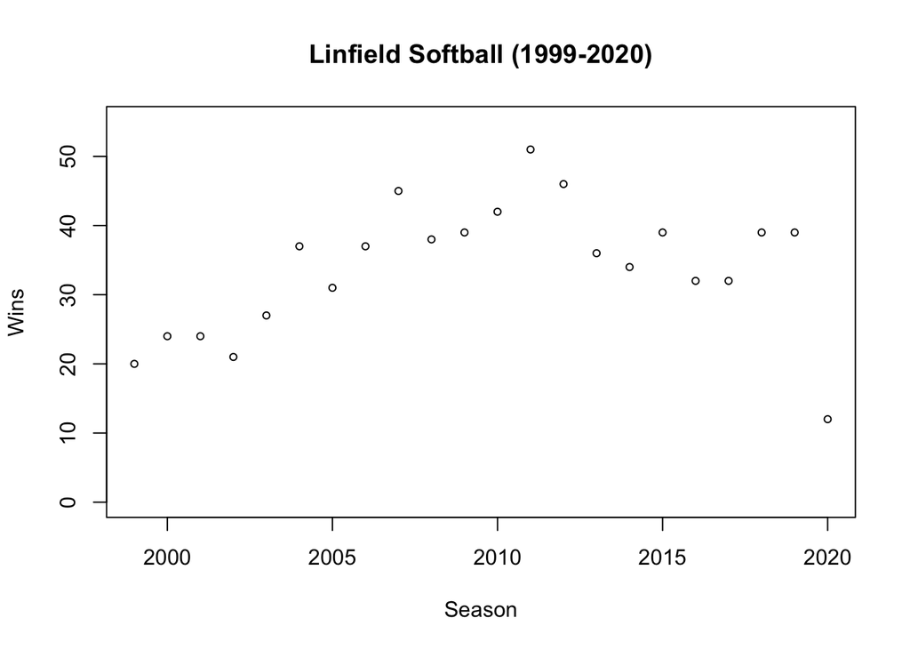

```r
plot(x=wildcats$Year, y=wildcats$W,cex=.7,
     main="Linfield Softball (1999-2020)",
     xlab="Season",
     ylab="Wins",
     ylim = c(0, 55))
```

ANSWER: Scatterplot of wins by season. This plot makes it clear that 2020 was a strange season. This visual deviation from the trend indicates that something “different” was going on. What was it?